# Analyzing RNA-binding protein profiles from eCLIP dat

Step 5: Explore the clustering of lncRNAs and mRNAs based on the proteins they bind to.

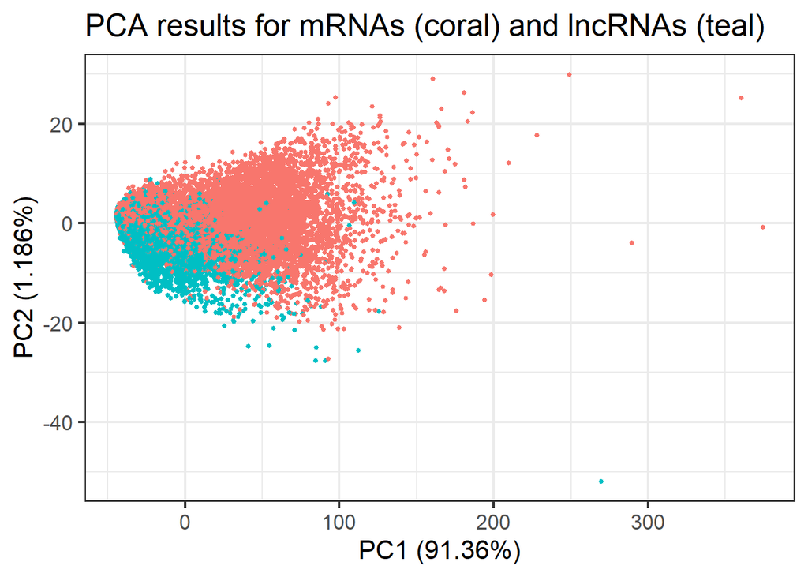

```r
### PCA on mRNAs and lncRNAs
se.pca <- prcomp(assay(se))
se.pca.var <- se.pca$sdev^2
se.pca.var.prop <- se.pca.var/sum(se.pca.var) * 100
se.PC1PC2 <- data.frame(se.pca$x[,1:2])
se.PC1PC2$colors <- rowData(se)$colors
ggplot(se.PC1PC2) +
  geom_point(aes(PC1, PC2, color = colors), size = 1) +
  theme(legend.position="none") +
  ggtitle('PCA results for mRNAs (coral) and lncRNAs (teal)') +
  xlab('PC1 (91.36%)') +
  ylab('PC2 (1.186%)')
```

Step 6: Visualize PCA results for lncRNAs only, accounting for density.

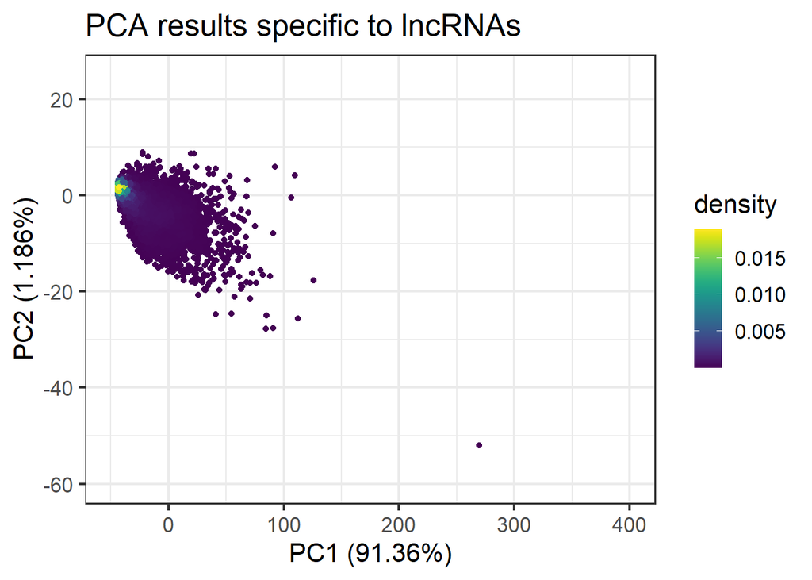

```r
### show results for lncRNAs only
se.lncRNA <- se.PC1PC2[lncRNAs,]
se.lncRNA$density <- get_density(se.lncRNA$PC1, se.lncRNA$PC2, n = 100)
ggplot(se.lncRNA) +
  geom_point(aes(PC1, PC2, color = density)) +
  scale_color_viridis() +
  xlim(-50, 400) +
  ylim(-60,  25) +
  ggtitle('PCA results specific to lncRNAs') +
  xlab('PC1 (91.36%)') +
  ylab('PC2 (1.186%)')
```

Step 7: Now visualize PCA results for mRNAs only, accounting for density.

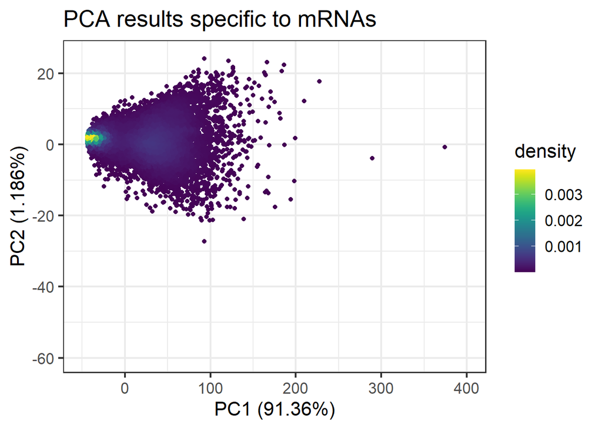

```r
### show results for mRNAs only
se.prtcod <- se.PC1PC2[prtcods,]
se.prtcod$density <- get_density(se.prtcod$PC1, se.prtcod$PC2, n = 100)
ggplot(se.prtcod) +
  geom_point(aes(PC1, PC2, color = density)) +
  scale_color_viridis() +
  xlim(-50, 400) +
  ylim(-60,  25) +
  ggtitle('PCA results specific to mRNAs') +
  xlab('PC1 (91.36%)') +
  ylab('PC2 (1.186%)')
```

Step 8: For the two high-density clusters on the mRNA-specific PCA, explore further with GO-term enrichment analyses.

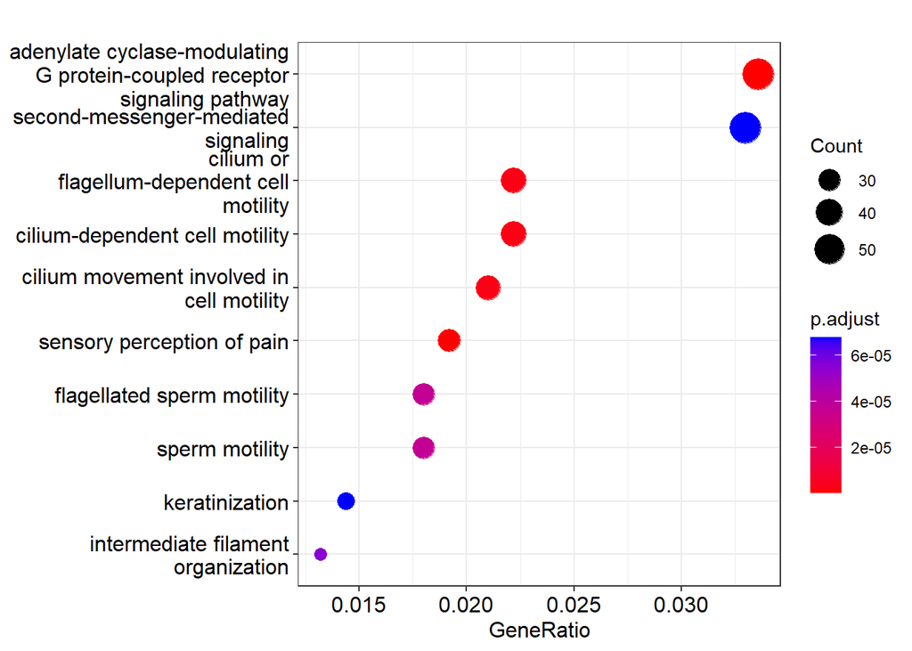

```r
### let's first look at the left-most high-density area
spot1 <- se.prtcod[which( se.prtcod$PC1 > -50 &
                          se.prtcod$PC1 < -20 &
                          se.prtcod$PC2 >  0 &
                          se.prtcod$PC2 <  3),]
gene1 <- gsub('\\..*', '', rownames(spot1))
GOE1 <- enrichGO(gene          = gene1,
                 keyType       = "ENSEMBL",
                 OrgDb         = org.Hs.eg.db,
                 ont           = "BP",
                 pAdjustMethod = "BH",
                 pvalueCutoff  = 0.01,
                 qvalueCutoff  = 0.05,
                 readable      = TRUE)
dotplot(GOE1)
```

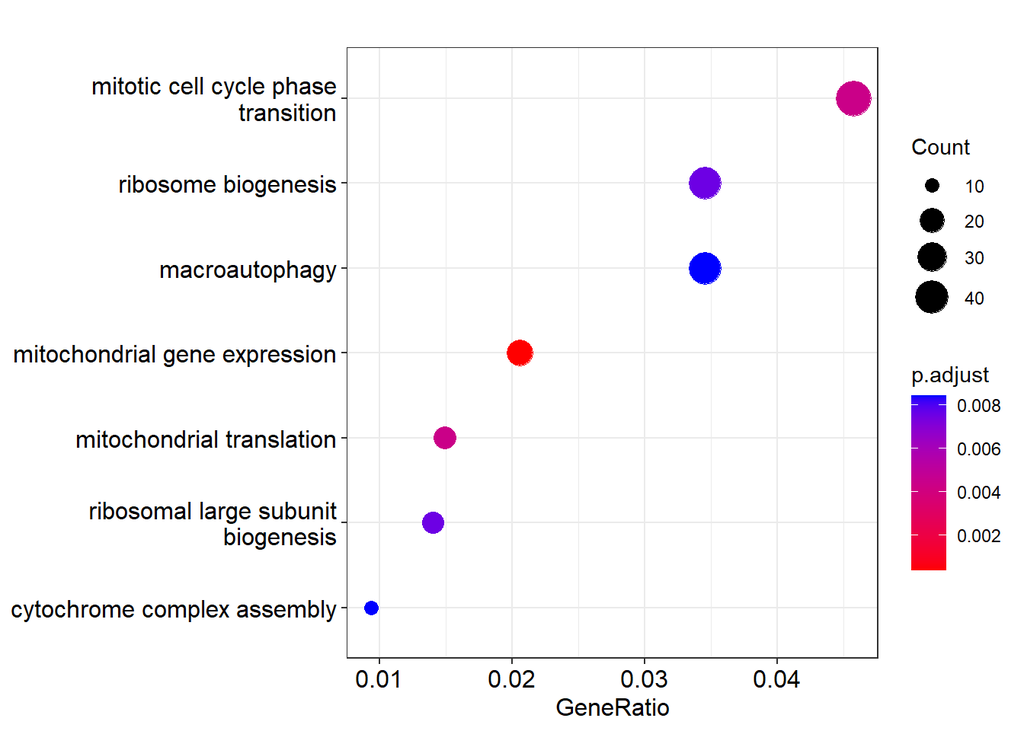

```r
### let's now look at the right-most high-density area
spot2 <- se.prtcod[which( se.prtcod$PC1 > 25 &
                          se.prtcod$PC1 < 50 &
                          se.prtcod$PC2 > -5 &
                          se.prtcod$PC2 <  5),]
gene2 <- gsub('\\..*', '', rownames(spot2))
GOE2 <- enrichGO(gene          = gene2,
                 keyType       = "ENSEMBL",
                 OrgDb         = org.Hs.eg.db,
                 ont           = "BP",
                 pAdjustMethod = "BH",
                 pvalueCutoff  = 0.01,
                 qvalueCutoff  = 0.05,
                 readable      = TRUE)
dotplot(GOE2)
```

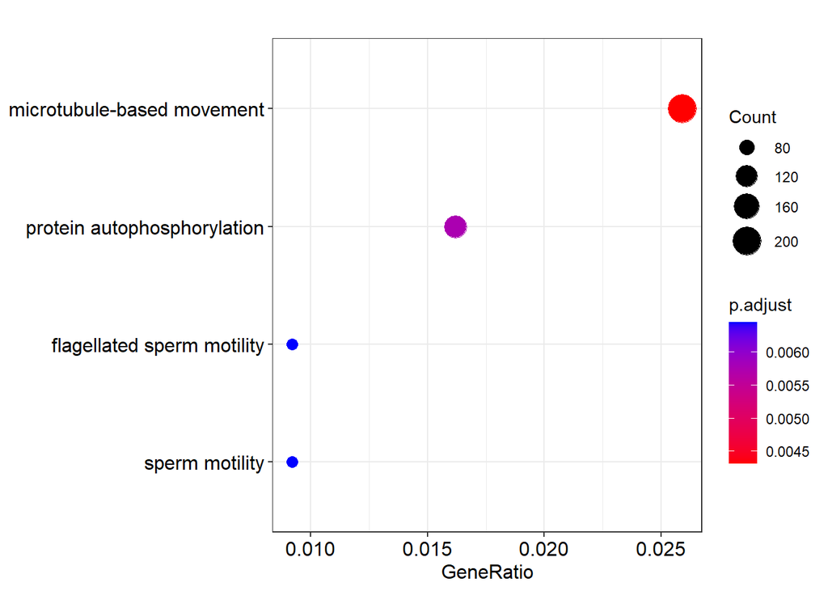

```r
### let's finally look at all the data points
gene3 <- gsub('\\..*', '', rownames(assay(se)))
GOE3 <- enrichGO(gene          = gene3,
                 keyType       = "ENSEMBL",
                 OrgDb         = org.Hs.eg.db,
                 ont           = "BP",
                 pAdjustMethod = "BH",
                 pvalueCutoff  = 0.01,
                 qvalueCutoff  = 0.05,
                 readable      = TRUE)
dotplot(GOE3)
```

## Discussion

### Clustering Analysis - Comparing K562 and HEPG2 Cells

Looking at the the PCA results for the 135 eCLIP proteins in K562 cells, we see that though the variance explained by PC1 and PC2 is small, YBX3 clearly stands out. In HEPG2 cells, 103 eCLIP experiments were performed. This could explain the difference in PCA results for the two cell lines. YBX3 eCLIP was not conducted in HEPG2.

YBX3 is a Y-Box binding protein and has been implicated in regulating amino acid homeostasis (Cooke et al, 2019). Its Entrez gene summary lists it as a cellular response to tumor necrosis factor and a negative regulator of programmed cell death. In chronic myeloid leukemia specifically, YBX3 is a regulator of proliferation (Sears et al, 2010). It could be interesting to study its RNA binding in a non-cancerous cell line. We did a GO enrichment analysis for the RNAs most bound by YBX3, but the results were inconclusive (code is commented out in the methods section).

Curious to see where XIST is located in the “PCA Results for lncRNAs plot” for K562, we found that it is right beside the lncRNA XACT. This pair stand relatively apart from the other lncRNAs. Whereas XIST is responsible for silencing an X chromosome in XX females, XACT is involved in X chromosome activation. The two work antagonistically (Vallot et al, 2017). XIST and XACT are both involved with the X chromosome, and excitingly not much is known about how XACT functions, the deep similarities in their RBP profiles may indicate that XACT is sequestering the RBPs critical for XIST to function. This might be possible if a protein deemed critical for XIST function, like SPEN, is not bound by XACT and prevents the RNA from actually performing the function of XIST despite having all the other protein resources necessary for repression. Unfortunately, this is a limitation of the dataset, as SPEN-binding has not been measured in eCLIP data and cannot be directly compared.

A comparison of the exact RBP profiles for XIST and XACT can be found here:

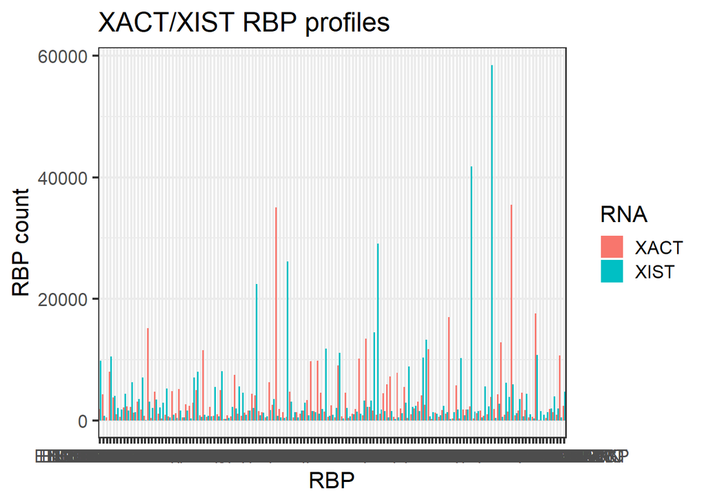

```r
XIST.data <- K562_counts["ENSG00000229807.13",]
XACT.data <- K562_counts["ENSG00000241743.4",]
combined.df <- as.data.frame(matrix(c(XIST.data, XACT.data), ncol=135, nrow=2))
colnames(combined.df) <- colnames(K562_counts)
rownames(combined.df) <- c("XIST", "XACT")
plotting.combined.df <- as.data.frame(t(combined.df))
plotting.combined.df$Gene <- colnames(K562_counts)
plotting.combined.df <- tidyr::pivot_longer(plotting.combined.df, cols=c('XIST', 'XACT'), names_to='RNA', values_to='count')
ggplot(plotting.combined.df, aes(x=Gene, y=as.numeric(count), fill=RNA)) + geom_bar(stat='identity', position='dodge') + xlab("RBP") + ylab("RBP count") + ggtitle("XACT/XIST RBP profiles")
```

Here, we identify many discrepancies between the profiles. Despite the similar clustering in the PCA these are by no means identical. However, it may also be worth looking at the data scaled by the total length of the RNAs.

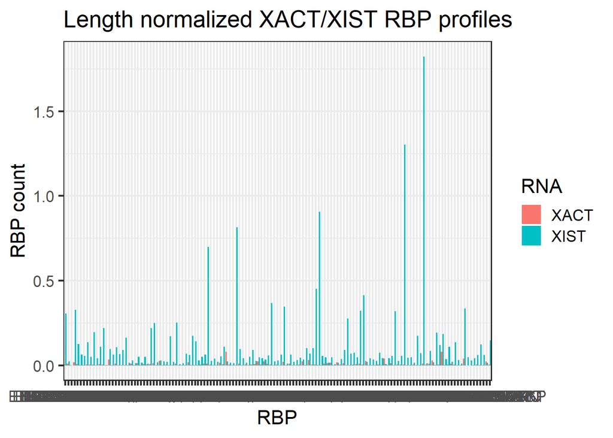

```r
XIST.length <- rowData(K562.se)["ENSG00000229807.13",]$Stop - rowData(K562.se)["ENSG00000229807.13",]$Start
XACT.length <- rowData(K562.se)["ENSG00000241743.4",]$Stop - rowData(K562.se)["ENSG00000241743.4",]$Start
plotting.combined.df <- as.data.frame(t(combined.df))
plotting.combined.df$XIST <- as.numeric(plotting.combined.df$XIST)/XIST.length
plotting.combined.df$XACT <- as.numeric(plotting.combined.df$XACT)/XACT.length
plotting.combined.df$Gene <- colnames(K562_counts)
plotting.combined.df <- tidyr::pivot_longer(plotting.combined.df, cols=c('XIST', 'XACT'), names_to='RNA', values_to='count')
ggplot(plotting.combined.df, aes(x=Gene, y=as.numeric(count), fill=RNA)) + geom_bar(stat='identity', position='dodge') + xlab("RBP") + ylab("RBP count") + ggtitle("Length normalized XACT/XIST RBP profiles")
```

Normalizing by length clearly increases the difference, with XIST expressing stronger binding to the proteins than XACT does. This seems to indicate that XIST likely has a higher density of RNA-binding protein motifs than XACT, and that length would not have a perfect correlation to the number of motifs in the transcript. This is certainly a feature that should be further investigated in a future experiment.

We identified other pairs of lncRNAs and attempted to see if they were involved in similar processes, but there were too many unknowns to make much headway. We do recognize that near XIST and XACT are the lncRNAs NEAT1 and MALAT1, both of which are involved in the formation and/or function of speckles, which are complex regions of local transcriptional activation. We also notice a particular long mRNA, FASN, is found in the farther reaches of the PCA plot, near these other four lncRNAs. This might indicate some amount of overlap with predicting length, as a longer RNA is more likely to bind more proteins, influencing the RBP profiles. Overall, these findings lead us to believe that a complex combination of the function, non-protein binding targets, and length of the transcript may all influence clustering proximity between RNAs. As more is learned about lncRNAs, perhaps given a plot similar to the PCA, a “connect-the-dot” approach can be used. Specifically, if an unknown lncRNA is positioned very near to a group of known lncRNAs, then perhaps it could give insight into the possible function of the unknown lncRNA.

## Conclusions

Further analysis into other cell types, particularly another female of a similar age to the K562 donor, would be helpful to determining the level of conservation in RBP expression across cell types. Controlling for age and being able to reference sex-specific RNAs including XIST would expand ability for cross-comparison of functionally documented RNAs. The exact details of binding profiles can be extremely beneficial in determining how RNAs function, however, a variety of features such as binding target and RNA length seem to influence the RBP profiles, not just the type of function.

```r
#K562 Cell Line
se_assay <- as.data.frame(assay(K562.se))
#Getting gene name
se_assay$ensem = gsub("\\..*","",row.names(se_assay))
se_assay$symbol = mapIds(org.Hs.eg.db,
                           keys = se_assay$ensem,
                           column = "SYMBOL",
                           keytype="ENSEMBL",
                           multiVals = "first")
se_assay <- subset(se_assay, select = c(136:137,1:135))
#Getting genetype
GeneType <- data.frame(GeneType = K562.se@elementMetadata@listData$Gene_type)
se_assay = cbind(se_assay,GeneType)
k562 <- (se_assay)
#changing colnames to the experiment target
targets2 <- as.data.frame(K562.se$Experiment.target)
colnames(k562)[3:137] <- targets2$`K562.se$Experiment.target`
#labeling cell line
CellLine = as.data.frame(rep("k562",dim(k562)[1]))
names(CellLine)[names(CellLine) == 'rep("k562", dim(k562)[1])'] <- "CellLine"
k562 = cbind(k562,CellLine)
#HEPG2 Cell Lines
se2_Hep_assay <- as.data.frame(assay(HEPG2.se))
#Getting gene name
se2_Hep_assay$ensem = gsub("\\..*","",row.names(se2_Hep_assay))
se2_Hep_assay$symbol = mapIds(org.Hs.eg.db,
                         keys = se2_Hep_assay$ensem,
                         column = "SYMBOL",
                         keytype="ENSEMBL",
                         multiVals = "first")
se2_Hep_assay <- subset(se2_Hep_assay, select = c(104:105,1:103))
#Getting genetype
GeneType <- data.frame(GeneType = HEPG2.se@elementMetadata@listData$Gene_type)
se2_Hep_assay = cbind(se2_Hep_assay,GeneType)
hepg2 <- (se2_Hep_assay)
#changing colnames to the experiment target
targets <- as.data.frame(HEPG2.se$Experiment.target)
colnames(hepg2)[3:105] <- targets$`HEPG2.se$Experiment.target`
#labeling cell line
CellLine = as.data.frame(rep("hepg2",dim(hepg2)[1]))
names(CellLine)[names(CellLine) == 'rep("hepg2", dim(hepg2)[1])'] <- "CellLine"
hepg2 = cbind(hepg2,CellLine)
#Seeing where they intersect
bL <- as.data.frame(intersect(names(k562), names(hepg2)))
bL <- as.character(intersect(names(k562), names(hepg2)))
#Extracting common colnames from both lines
hepg2 <- hepg2 %>% dplyr::select(bL)
k562 <- k562 %>% dplyr::select(bL)
#combining both lines
bothLines <- rbind(k562,hepg2)
```

## References

Nostrand, E.L. et al. (2016). Robust transcriptome-wide discovery of RNA-binding protein binding sites with enhanced CLIP (eCLIP). Nature Methods, 13(6), 508-514. https://doi:10.1038/nmeth.3810

Nostrand, E.L. Yeo, G. (2015). eCLIP Standard Operating Procedure v1.P 20151108. ENCODE, ENCSR489RJI: Documents. https://www.encodeproject.org/experiments/ENCSR489RJI/

Yeo, G. (2020) eCLIP-seq Processing Pipeline v2.0. ENCODE, ENCSR268ETU: Documents. https://www.encodeproject.org/experiments/ENCSR268ETU/

Cooke, A., Schwarzl, T., Huppertz, I., Kramer, G., Mantas, P., Alleaume, A. M., Huber, W., Krijgsveld, J., & Hentze, M. W. (2019). The RNA-Binding Protein YBX3 Controls Amino Acid Levels by Regulating SLC mRNA Abundance. Cell reports, 27(11), 3097–3106.e5. https://doi.org/10.1016/j.celrep.2019.05.039

Sears, D., Luong, P., Yuan, M., Nteliopoulos, G., Man, Y. K., Melo, J. V., & Basu, S. (2010). Functional phosphoproteomic analysis reveals cold-shock domain protein A to be a Bcr-Abl effector-regulating proliferation and transformation in chronic myeloid leukemia. Cell death & disease, 1(11), e93. https://doi.org/10.1038/cddis.2010.72

Vallot, C., Patrat, C., Collier, A. J., Huret, C., Casanova, M., Liyakat Ali, T. M., Tosolini, M., Frydman, N., Heard, E., Rugg-Gunn, P. J., & Rougeulle, C. (2017). XACT Noncoding RNA Competes with XIST in the Control of X Chromosome Activity during Human Early Development. Cell stem cell, 20(1), 102–111. https://doi.org/10.1016/j.stem.2016.10.014